# Homework 09

The kernel-tuning question moved here from Homework 08. A solution for Question 1 will be available after Monday, October 26, 2026. No solution will be provided for Question 2.

## Question 1: Choosing an SVM kernel

Use `saheart.csv` from the combined ZIP. As in Homework 7, predict `chd` using the same nine predictors, coding `famhist` as 1 for `Absent` and 2 for `Present`.

Compare SVMs with a linear kernel, polynomial kernels of degrees 2 (quadratic), 3, and 4, and a radial basis kernel. Choose **no more than 20 candidate settings in total** across these kernels. Vary the cost $C$ for each kernel and the radial scale $\gamma$ for the radial kernel. State any other kernel settings you hold fixed.

Divide the observations into five folds yourself and use the same folds for all candidates. Standardize predictors using only the fitting observations in each fold. Report the candidate settings and their mean cross-validation misclassification rates. Which kernel and settings do you prefer? Give a brief justification.

### Solution

I used five stratified folds, assigned once with seed 43209 and reused for all 18 candidates. In every fold, each predictor was centered and scaled using only that fold’s fitting observations. The polynomial kernels use `gamma = 1/9` and `coef0 = 1`; the radial kernels use the two listed values of `gamma`. The linear kernel does not use `gamma`, `degree`, or `coef0`.

```r
library(e1071)

heart <- read.csv("data/saheart.csv")
heart$famhist <- ifelse(heart$famhist == "Absent", 1, 2)
X <- as.matrix(heart[names(heart) != "chd"])
y <- factor(heart$chd, levels = c(0, 1))

set.seed(43209)
fold_id <- integer(nrow(X))
for (class_value in levels(y)) {
  class_rows <- sample(which(y == class_value))
  fold_id[class_rows] <- rep(1:5, length.out = length(class_rows))
}

cost_values <- c(0.1, 1, 10)
polynomial <- do.call(rbind, lapply(2:4, function(d) {
  data.frame(kernel = "polynomial", degree = d, cost = cost_values,
             gamma = 1 / ncol(X), coef0 = 1)
}))
linear <- data.frame(kernel = "linear", degree = NA_integer_,
                     cost = cost_values, gamma = NA_real_, coef0 = NA_real_)
radial <- do.call(rbind, lapply(c(0.05, 0.2), function(g) {
  data.frame(kernel = "radial", degree = NA_integer_, cost = cost_values,
             gamma = g, coef0 = NA_real_)
}))
candidates <- rbind(linear, polynomial, radial)

fold_error <- matrix(NA_real_, nrow(candidates), 5)
for (i in seq_len(nrow(candidates))) {
  setting <- candidates[i, ]
  for (fold in 1:5) {
    train_rows <- fold_id != fold
    valid_rows <- fold_id == fold
    x_train <- X[train_rows, , drop = FALSE]
    x_valid <- X[valid_rows, , drop = FALSE]

    train_center <- colMeans(x_train)
    train_scale <- apply(x_train, 2, sd)
    x_train <- sweep(sweep(x_train, 2, train_center, "-"), 2, train_scale, "/")
    x_valid <- sweep(sweep(x_valid, 2, train_center, "-"), 2, train_scale, "/")

    fit <- svm(
      x = x_train, y = y[train_rows], kernel = setting$kernel,
      cost = setting$cost,
      degree = if (is.na(setting$degree)) 3 else setting$degree,
      gamma = if (is.na(setting$gamma)) 1 / ncol(X) else setting$gamma,
      coef0 = if (is.na(setting$coef0)) 1 else setting$coef0,
      scale = FALSE
    )
    predicted <- predict(fit, x_valid)
    fold_error[i, fold] <- mean(predicted != y[valid_rows])
  }
}

cv_results <- candidates
cv_results$mean_error <- rowMeans(fold_error)
cv_results$candidate <- ifelse(
  cv_results$kernel == "polynomial",
  paste0("polynomial d=", cv_results$degree),
  cv_results$kernel
)
cv_results$gamma_report <- ifelse(
  is.na(cv_results$gamma), "n/a", format(cv_results$gamma, trim = TRUE)
)
cv_results$coef0_report <- ifelse(
  is.na(cv_results$coef0), "n/a", format(cv_results$coef0, trim = TRUE)
)

complexity <- ifelse(
  cv_results$kernel == "linear", 1,
  ifelse(cv_results$kernel == "polynomial", cv_results$degree + 1, 6)
)
fold_sizes <- tabulate(fold_id, nbins = 5)
pooled_errors <- rowSums(sweep(fold_error, 2, fold_sizes, "*"))
within_one_case <- which(
  pooled_errors <= min(pooled_errors) + 1
)
best_order <- within_one_case[
  order(complexity[within_one_case], cv_results$cost[within_one_case])
]
best <- cv_results[best_order[1], ]
display_order <- order(cv_results$mean_error, complexity, cv_results$cost)
results_table <- data.frame(
  Kernel = cv_results$candidate,
  C = cv_results$cost,
  gamma = cv_results$gamma_report,
  coef0 = cv_results$coef0_report,
  `Mean CV error` = cv_results$mean_error,
  check.names = FALSE
)
results_table <- results_table[display_order, ]
knitr::kable(results_table, digits = 4,
             caption = "Five-fold cross-validation results (18 candidates)")
```

Five-fold cross-validation results (18 candidates)

|  | Kernel | C | gamma | coef0 | Mean CV error |
| --- | --- | --- | --- | --- | --- |
| 7 | polynomial d=3 | 0.1 | 0.1111111 | 1 | 0.2772 |
| 1 | linear | 0.1 | n/a | n/a | 0.2773 |
| 14 | radial | 1.0 | 0.0500000 | n/a | 0.2793 |
| 4 | polynomial d=2 | 0.1 | 0.1111111 | 1 | 0.2836 |
| 5 | polynomial d=2 | 1.0 | 0.1111111 | 1 | 0.2923 |
| 10 | polynomial d=4 | 0.1 | 0.1111111 | 1 | 0.2924 |
| 2 | linear | 1.0 | n/a | n/a | 0.2924 |
| 3 | linear | 10.0 | n/a | n/a | 0.2924 |
| 17 | radial | 1.0 | 0.2000000 | n/a | 0.2946 |
| 6 | polynomial d=2 | 10.0 | 0.1111111 | 1 | 0.3032 |
| 15 | radial | 10.0 | 0.0500000 | n/a | 0.3033 |
| 8 | polynomial d=3 | 1.0 | 0.1111111 | 1 | 0.3140 |
| 18 | radial | 10.0 | 0.2000000 | n/a | 0.3313 |
| 11 | polynomial d=4 | 1.0 | 0.1111111 | 1 | 0.3334 |
| 9 | polynomial d=3 | 10.0 | 0.1111111 | 1 | 0.3335 |
| 13 | radial | 0.1 | 0.0500000 | n/a | 0.3463 |
| 16 | radial | 0.1 | 0.2000000 | n/a | 0.3463 |
| 12 | polynomial d=4 | 10.0 | 0.1111111 | 1 | 0.3487 |

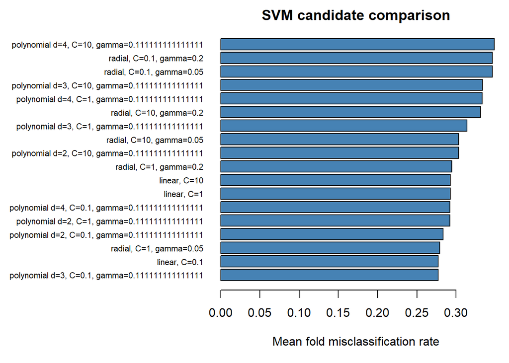

```r
labels <- paste0(cv_results$candidate, ", C=", cv_results$cost,
                 ifelse(is.na(cv_results$gamma), "",
                        paste0(", gamma=", cv_results$gamma)))
par(mar = c(5, 15, 2, 1))
barplot(cv_results$mean_error[display_order],
        names.arg = labels[display_order], horiz = TRUE, las = 1,
        cex.names = 0.7, xlab = "Mean fold misclassification rate",
        main = "SVM candidate comparison", col = "steelblue")
```

```r
best_oof_count <- pooled_errors[best_order[1]]
cat(sprintf(
  "\nPreferred setting: %s, C=%g, gamma=%s, mean five-fold error=%.4f.\n",
  best$candidate, best$cost, best$gamma_report, best$mean_error
))
```

```
Preferred setting: linear, C=0.1, gamma=n/a, mean five-fold error=0.2773.
```

```r
cat(sprintf(
  "Pooled out-of-fold error: %d/%d = %.4f.\n",
  best_oof_count, nrow(X), best_oof_count / nrow(X)
))
```

```
Pooled out-of-fold error: 128/462 = 0.2771.
```

The lowest observed rate is for the cubic polynomial with `C = 0.1`, but its advantage over the linear SVM with `C = 0.1` is much smaller than one observation across the full dataset. I therefore treat candidates within one observation of the minimum as effectively tied and prefer the simpler linear SVM, with smaller `C` breaking any remaining tie. The table and figure show the full candidate comparison. The selected error is a cross-validation estimate, not an independent test-set estimate.

## Question 2: Write and use a short SVM analysis skill

In Homework 8, you reviewed another student’s skill. Review the comments and suggestions you received on your own Homework 7 skill. Use what you learned from both sides of the peer review to write a new, shorter skill for SVM model fitting.

Create a dataset-independent `SKILL.md` with YAML frontmatter and an instruction body of no more than 50 lines. Load it only when explicitly invoked. It should guide the agent to assess data suitability; choose and justify kernels; tune relevant parameters; select a model using appropriate evaluation; provide a compact figure and table; interpret numerical results; and prioritize the evidence needed to justify the model in a one-page report at 11-point font.

Apply the skill to the same `saheart.csv` response and predictors as Question 1, including the same `famhist` coding. Include the one-page analysis report in the submission and append the complete skill afterward.

### Solution

I explicitly applied `SKILL.md` to this dataset. I did not find peer-review comments in the downloaded workspace, so I used the assignment checklist and standard SVM validation safeguards. The data are suitable for binary SVM classification: there are 462 complete observations, nine numerical predictors, and two response classes (`chd = 0`: 302; `chd = 1`: 160). The moderate class imbalance makes it useful to report class-specific performance in addition to overall misclassification. Linear, low-degree polynomial, and radial kernels cover increasingly flexible boundaries; five-fold stratified cross-validation tunes 18 settings with common folds, and fold-only standardization prevents leakage.

To estimate the performance of the model-selection procedure, the following nested cross-validation repeats that tuning in each outer training set. The inner folds use the same 18 settings and the skill’s one-error parsimony rule; preprocessing is refit in every inner and outer training set.

```r
make_stratified_folds <- function(response, k) {
  folds <- integer(length(response))
  for (class_value in levels(response)) {
    rows <- sample(which(response == class_value))
    folds[rows] <- rep(seq_len(k), length.out = length(rows))
  }
  folds
}

set.seed(43210)
outer_fold <- make_stratified_folds(y, 5)
outer_prediction <- factor(rep(NA_character_, length(y)), levels = levels(y))
outer_choice <- integer(5)

for (outer in 1:5) {
  outer_train <- outer_fold != outer
  outer_valid <- outer_fold == outer
  x_outer <- X[outer_train, , drop = FALSE]
  y_outer <- droplevels(y[outer_train])
  inner_fold <- make_stratified_folds(y_outer, 5)
  inner_sizes <- tabulate(inner_fold, nbins = 5)
  inner_error <- matrix(NA_real_, nrow(candidates), 5)

  for (i in seq_len(nrow(candidates))) {
    setting <- candidates[i, ]
    for (inner in 1:5) {
      inner_train <- inner_fold != inner
      inner_valid <- inner_fold == inner
      x_fit <- x_outer[inner_train, , drop = FALSE]
      x_valid <- x_outer[inner_valid, , drop = FALSE]
      center <- colMeans(x_fit)
      scale <- apply(x_fit, 2, sd)
      x_fit <- sweep(sweep(x_fit, 2, center, "-"), 2, scale, "/")
      x_valid <- sweep(sweep(x_valid, 2, center, "-"), 2, scale, "/")
      fit <- svm(
        x = x_fit, y = y_outer[inner_train], kernel = setting$kernel,
        cost = setting$cost,
        degree = if (is.na(setting$degree)) 3 else setting$degree,
        gamma = if (is.na(setting$gamma)) 1 / ncol(X) else setting$gamma,
        coef0 = if (is.na(setting$coef0)) 1 else setting$coef0,
        scale = FALSE
      )
      inner_error[i, inner] <- mean(
        predict(fit, x_valid) != y_outer[inner_valid]
      )
    }
  }

  inner_counts <- rowSums(sweep(inner_error, 2, inner_sizes, "*"))
  tied <- which(inner_counts <= min(inner_counts) + 1)
  chosen <- tied[order(complexity[tied], candidates$cost[tied])][1]
  outer_choice[outer] <- chosen
  setting <- candidates[chosen, ]

  center <- colMeans(x_outer)
  scale <- apply(x_outer, 2, sd)
  x_fit <- sweep(sweep(x_outer, 2, center, "-"), 2, scale, "/")
  x_valid <- sweep(sweep(X[outer_valid, , drop = FALSE], 2, center, "-"),
                   2, scale, "/")
  fit <- svm(
    x = x_fit, y = y_outer, kernel = setting$kernel, cost = setting$cost,
    degree = if (is.na(setting$degree)) 3 else setting$degree,
    gamma = if (is.na(setting$gamma)) 1 / ncol(X) else setting$gamma,
    coef0 = if (is.na(setting$coef0)) 1 else setting$coef0,
    scale = FALSE
  )
  outer_prediction[outer_valid] <- predict(fit, x_valid)
}

nested_cm <- table(
  Observed = factor(y, levels = levels(y)),
  Predicted = factor(outer_prediction, levels = levels(y))
)
cat("Nested five-fold out-of-fold confusion matrix:\n")
```

```
Nested five-fold out-of-fold confusion matrix:
```

```r
print(nested_cm)
```

```
        Predicted
Observed   0   1
       0 257  45
       1  83  77
```

```r
nested_error <- mean(outer_prediction != y)
cat(sprintf("Nested CV error: %d/%d = %.4f.\n",
            sum(outer_prediction != y), length(y), nested_error))
```

```
Nested CV error: 128/462 = 0.2771.
```

```r
cat(sprintf("Sensitivity: %.3f; specificity: %.3f.\n",
            nested_cm["1", "1"] / sum(nested_cm["1", ]),
            nested_cm["0", "0"] / sum(nested_cm["0", ])))
```

```
Sensitivity: 0.481; specificity: 0.851.
```

```r
cat("Selected outer-fold candidates:",
    paste(cv_results$candidate[outer_choice], collapse = ", "), "\n")
```

```
Selected outer-fold candidates: polynomial d=3, radial, linear, linear, linear
```

```r
final_setting <- candidates[best_order[1], ]
full_center <- colMeans(X)
full_scale <- apply(X, 2, sd)
X_standardized <- sweep(sweep(X, 2, full_center, "-"), 2, full_scale, "/")
final_fit <- svm(
  x = X_standardized, y = y, kernel = final_setting$kernel,
  cost = final_setting$cost,
  degree = if (is.na(final_setting$degree)) 3 else final_setting$degree,
  gamma = if (is.na(final_setting$gamma)) 1 / ncol(X) else final_setting$gamma,
  coef0 = if (is.na(final_setting$coef0)) 1 else final_setting$coef0,
  scale = FALSE
)
cat("Final full-data candidate:", cv_results$candidate[best_order[1]],
    "C =", final_setting$cost, "; support vectors =",
    sum(final_fit$nSV), "\n")
```

```
Final full-data candidate: linear C = 0.1 ; support vectors = 283
```

The five outer folds estimate the error of the complete tuning-and-selection process, while the initial five-fold table is used to choose the final candidate. The selected full-data model is linear SVM with `C = 0.1`; its apparent fit is not reported as a performance estimate. The nested estimate is 128/462 errors (27.71%), with 48.1% sensitivity and 85.1% specificity. Thus overall error improves on the 34.6% majority-class baseline, but the selected procedure still misses many `chd = 1` cases. With no stated false-negative costs, the assignment’s misclassification criterion is retained; a risk-focused application should select and evaluate using a cost-sensitive or class-balanced metric.